# Machine Learning Prediction Project

Lee Shee Chia

#### Background

Using devices such as Jawbone Up, Nike FuelBand, and Fitbit it is now possible to collect a large amount of data about personal activity relatively inexpensively. These type of devices are part of the quantified self movement - a group of enthusiasts who take measurements about themselves regularly to improve their health, to find patterns in their behavior, or because they are tech geeks. One thing that people regularly do is quantify how much of a particular activity they do, but they rarely quantify how well they do it. In this project, your goal will be to use data from accelerometers on the belt, forearm, arm, and dumbell of 6 participants. They were asked to perform barbell lifts correctly and incorrectly in 5 different ways. More information is available from the website here: http://groupware.les.inf.puc-rio.br/har (see the section on the Weight Lifting Exercise Dataset).

#### Data

The training data for this project are available here:

https://d396qusza40orc.cloudfront.net/predmachlearn/pml-training.csv

The test data are available here:

https://d396qusza40orc.cloudfront.net/predmachlearn/pml-testing.csv

#### Packages, Libraries, Seed

```r
library(caret)
library(randomForest)
```

```r
library(rpart)
library(rpart.plot)
library(RColorBrewer)
library(rattle)
set.seed(7714)
```

#### Getting and Cleaning Data

```r
# Read data
training <- read.csv("C:/Users/Guest/Desktop/R/module 8/pml-training.csv", na.strings=c("NA","#DIV/0!", ""))
testing <- read.csv('C:/Users/Guest/Desktop/R/module 8/pml-testing.csv', na.strings=c("NA","#DIV/0!", ""))
dim(training)
```

```
## [1] 19622   160
```

```r
dim(testing)
```

```
## [1]  20 160
```

```r
# Delete columns with all missing values
training <- training[,colSums(is.na(training)) == 0]
testing <- testing[,colSums(is.na(testing)) == 0]

# Delete variables which are irrelevant to project
training <- training[,-c(1:7)]
testing <- testing[,-c(1:7)]
```

#### Partioning the training set

To perform cross-validation, the training data set is partioned into 2 sets: subTraining (75%) and subTesting (25%).

```r
sub <- createDataPartition(y=training$classe, p=0.75, list=FALSE)
subTraining <- training[sub, ]
subTesting <- training[-sub, ]
```

#### Using ML algorithms for prediction: 1. Decision Tree

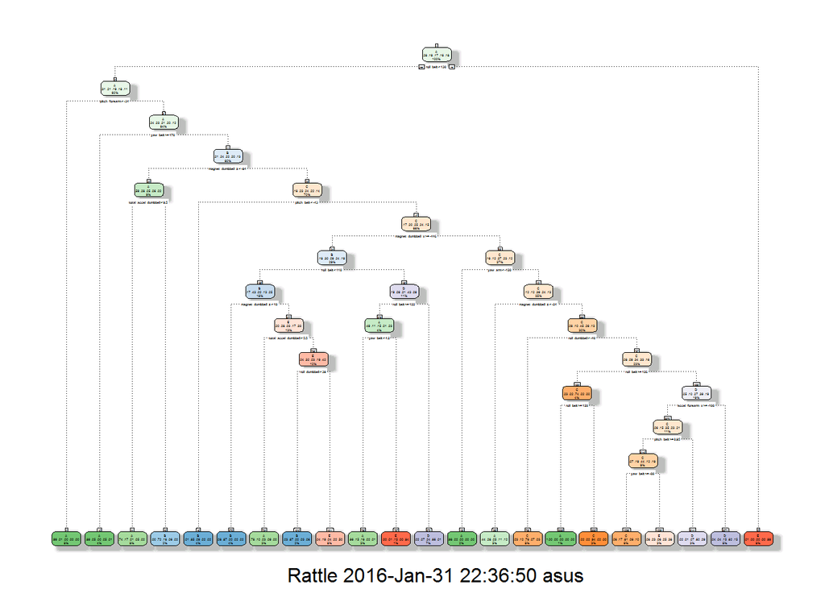

```r
modFit1 <- rpart(classe ~ ., data=subTraining, method="class")
predict1 <- predict(modFit1, subTesting, type = "class")
fancyRpartPlot(modFit1)
```

```r
confusionMatrix(predict1, subTesting$classe)
```

```
## Confusion Matrix and Statistics
##
##           Reference
## Prediction    A    B    C    D    E
##          A 1280  195   62   71   41
##          B   22  482   41   20   16
##          C   37  102  574   48   37
##          D   30   46  147  531   84
##          E   26  124   31  134  723
##
## Overall Statistics
##
##                Accuracy : 0.7321
##                  95% CI : (0.7194, 0.7444)
##     No Information Rate : 0.2845
##     P-Value [Acc > NIR] : < 2.2e-16
##
##                   Kappa : 0.6592
##  Mcnemar's Test P-Value : < 2.2e-16
##
## Statistics by Class:
##
##                      Class: A Class: B Class: C Class: D Class: E
## Sensitivity            0.9176  0.50790   0.6713   0.6604   0.8024
## Specificity            0.8948  0.97497   0.9447   0.9251   0.9213
## Pos Pred Value         0.7762  0.82960   0.7193   0.6337   0.6965
## Neg Pred Value         0.9647  0.89197   0.9316   0.9329   0.9540
## Prevalence             0.2845  0.19352   0.1743   0.1639   0.1837
## Detection Rate         0.2610  0.09829   0.1170   0.1083   0.1474
## Detection Prevalence   0.3363  0.11847   0.1627   0.1709   0.2117
## Balanced Accuracy      0.9062  0.74144   0.8080   0.7928   0.8619
```

#### Using ML algorithms for prediction: 2. Random Forest

```r
modFit2 <- randomForest(classe ~. , data=subTraining, method="class")
predict2 <- predict(modFit2, subTesting, type = "class")
confusionMatrix(predict2, subTesting$classe)
```

```
## Confusion Matrix and Statistics
##
##           Reference
## Prediction    A    B    C    D    E
##          A 1395    5    0    0    0
##          B    0  942    4    0    0
##          C    0    2  849   12    0
##          D    0    0    2  790    1
##          E    0    0    0    2  900
##
## Overall Statistics
##
##                Accuracy : 0.9943
##                  95% CI : (0.9918, 0.9962)
##     No Information Rate : 0.2845
##     P-Value [Acc > NIR] : < 2.2e-16
##
##                   Kappa : 0.9928
##  Mcnemar's Test P-Value : NA
##
## Statistics by Class:
##
##                      Class: A Class: B Class: C Class: D Class: E
## Sensitivity            1.0000   0.9926   0.9930   0.9826   0.9989
## Specificity            0.9986   0.9990   0.9965   0.9993   0.9995
## Pos Pred Value         0.9964   0.9958   0.9838   0.9962   0.9978
## Neg Pred Value         1.0000   0.9982   0.9985   0.9966   0.9998
## Prevalence             0.2845   0.1935   0.1743   0.1639   0.1837
## Detection Rate         0.2845   0.1921   0.1731   0.1611   0.1835
## Detection Prevalence   0.2855   0.1929   0.1760   0.1617   0.1839
## Balanced Accuracy      0.9993   0.9958   0.9948   0.9909   0.9992
```

#### Conclusion

Random Forest is a better model compared to Decision Tree where accuracy : Random Forest model 0.9943 (95% CI: (0.9918, 0.9962)) ; Decision Tree model 0.7321 (95% CI: (0.7194, 0.7444))

#### Generating files for submission

```r
predictFit <- predict(modFit2, testing, type="class")
pml_write_files = function(x){
  n = length(x)
  for(i in 1:n){
    filename = paste0("problem_id_",i,".txt")
    write.table(x[i],file=filename,quote=FALSE,row.names=FALSE,col.names=FALSE)
  }
}

pml_write_files(predictFit)
```